# Aids Drug

Lourdes Orozco!

May 11, 2019

# 1 Introduction

A new preventative aides (abacavirinol) is under test in clinical trials. Analyze the effectiveness of this drug across the board. Consider population subgroups by gender, drug use, and sexual orientation. Finish this!

The first question is this: does abacavirinol have any affect on wheter one contracts AIDS or not?

$H_0:$ avacabirinol has no effect on whether one contracts AIDS or not. $H_1:S avacabirinol has an effect on wheter on contracts. AIDS or not.

The reamining questions are: does abacavirinol have a different effect base on gender.

$H_0:$ gender has no effect on whether abacavirinol offers any protection against contracting AIDS.

# 2 Methods

For each hypothesis test the graphical summary will be a bar plot, the numerical summary will be a cross tabulation, and a chi-squared test will be used for the inferential results.

# 3 Results Gen Population Did vaccine make a difference?

Is the vaccine effective in the general population?

## 3.1 Descriptive Results

### 3.1.1 Graphical Descriptive Results

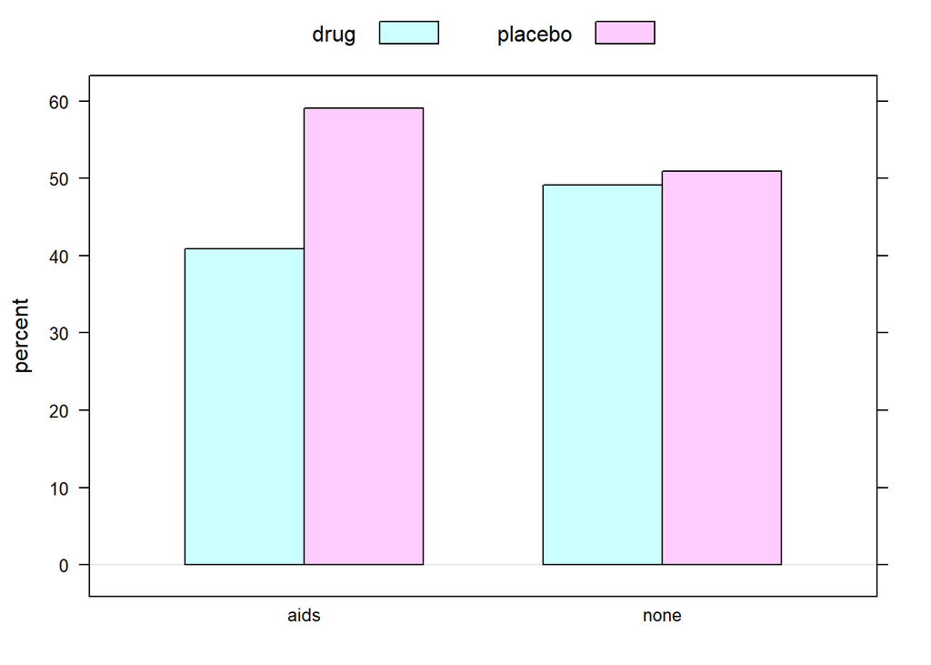

```r
barchartGC(~infected+treatment, data=avast, type='percent')
```

This bar chart shows that persons that recieved the drug got aids it appears is smaller then those that got the placebo.

### 3.1.2 Numerical Descriptive Results

```r
genTable = xtabs(~treatment+infected, data=avast)
print(genTable)
```

```
##          infected
## treatment  aids  none
##   drug      423 10168
##   placebo   612 10540
```

```r
rowPerc(genTable)
```

```
##          infected
## treatment   aids   none  Total
##   drug      3.99  96.01 100.00
##   placebo   5.49  94.51 100.00
```

```r
colPerc(genTable)
```

```
##          infected
## treatment   aids  none
##   drug     40.87  49.1
##   placebo  59.13  50.9
##   Total   100.00 100.0
```

## 3.2 Inferential Results

```r
chisqtestGC(~treatment+infected, data=avast)
```

```
## Pearson's Chi-squared test with Yates' continuity correction
##
## Observed Counts:
##          infected
## treatment  aids  none
##   drug      423 10168
##   placebo   612 10540
##
## Counts Expected by Null:
##          infected
## treatment   aids     none
##   drug    504.15 10086.85
##   placebo 530.85 10621.15
##
## Contributions to the chi-square statistic:
##          infected
## treatment  aids  none
##   drug    13.06  0.65
##   placebo 12.40  0.62
##
##
## Chi-Square Statistic = 26.4104
## Degrees of Freedom of the table = 1
## P-Value = 0
```

The P value is 0. The p-value was 0,so we reject the null hypothesis which was it does not make a difference because it does make make a difference.

# 4 Discussion and Conclusion

OVERALL Null hypothesis is that the vaccine has no effect on the general infected population. The p-value was 0,so we reject the null hypothesis which is it does not make a difference because it does make does make a difference.

# 5 Results Gender

does gender effect the vaccine effectiveness?

## 5.1 Descriptive Results

### 5.1.1 Graphical Descriptive Results

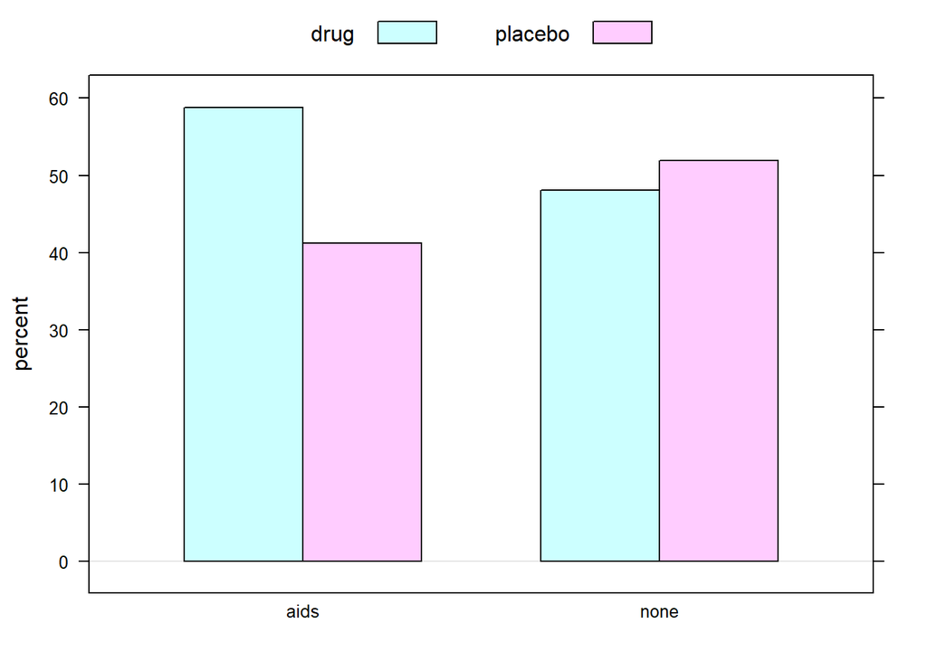

```r
barchartGC(~infected+treatment, data=avastF, type='percent')
```

The woman that received the drug had a high probability of contracting aids so it would be best if women did not get the treatment or vaccine.

### 5.1.2 Numerical Descriptive Results

```r
genTable = xtabs(~infected+treatment, data=avastF)
print(genTable)
```

```
##         treatment
## infected drug placebo
##     aids  210     147
##     none 5484    5927
```

the drug has a high risk facto on the woman, their are likely to contract aids.

## 5.2 Inferential Results

```r
chisqtestGC(~infected+treatment, data=avastF)
```

```
## Pearson's Chi-squared test with Yates' continuity correction
##
## Observed Counts:
##         treatment
## infected drug placebo
##     aids  210     147
##     none 5484    5927
##
## Counts Expected by Null:
##         treatment
## infected    drug placebo
##     aids  172.74  184.26
##     none 5521.26 5889.74
##
## Contributions to the chi-square statistic:
##         treatment
## infected drug placebo
##     aids 8.04    7.54
##     none 0.25    0.24
##
##
## Chi-Square Statistic = 15.6339
## Degrees of Freedom of the table = 1
## P-Value = 1e-04
```

```r
fisher.test(genTable)
```

```
##
##  Fisher's Exact Test for Count Data
##
## data:  genTable
## p-value = 6.596e-05
## alternative hypothesis: true odds ratio is not equal to 1
## 95 percent confidence interval:
##  1.240408 1.925729
## sample estimates:
## odds ratio
##   1.543902
```

The woman that received the drug had a high probability of contracting aids so it would be best if woman did not get the treatment. It’s significant in the wrong direction, if it worked it would reduce the odds ratio, but it did not work because it incresed the odds of getting aids.

# 6 Discussion and Conclusion

GENDER The results demonstrate that the vaccine does affect the results. We reject the Null hypothesis that the vaccine does not affect females, it does affect females and they are more likely to get aids if vaccinated.

# 7 Results drug users

Will being an IV drug user affect the effectivness of the vaccine?

## 7.1 Descriptive Results

### 7.1.1 Graphical Descriptive Results

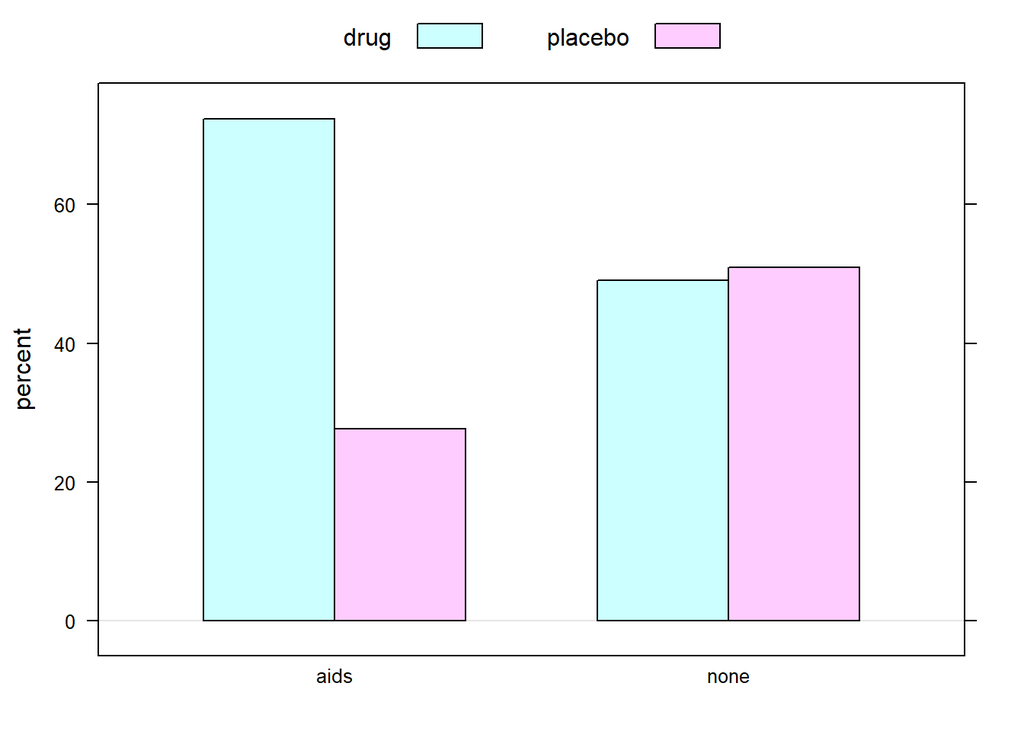

```r
barchartGC(~infected+treatment, data=avastIV, type='percent')
```

### 7.1.2 Numerical Descriptive Results

```r
genTable = xtabs(~treatment+infected, data=avastIV)
print(genTable)
```

```
##          infected
## treatment aids none
##   drug      76 1007
##   placebo   29 1046
```

This numerical chart shows the significant difference between placebo drug and actual drub in the IV drug population.

## 7.2 Inferential Results

```r
chisqtestGC(~treatment+infected, data=avastIV)
```

```
## Pearson's Chi-squared test with Yates' continuity correction
##
## Observed Counts:
##          infected
## treatment aids none
##   drug      76 1007
##   placebo   29 1046
##
## Counts Expected by Null:
##          infected
## treatment  aids    none
##   drug    52.69 1030.31
##   placebo 52.31 1022.69
##
## Contributions to the chi-square statistic:
##          infected
## treatment  aids  none
##   drug    10.31  0.53
##   placebo 10.38  0.53
##
##
## Chi-Square Statistic = 20.8264
## Degrees of Freedom of the table = 1
## P-Value = 0
```

# 8 Discussion and Conclusion

# 9 Results sexual orientation

Is the vaccine effectevness affceted by sexual orientation?

## 9.1 Descriptive Results

### 9.1.1 Graphical Descriptive Results

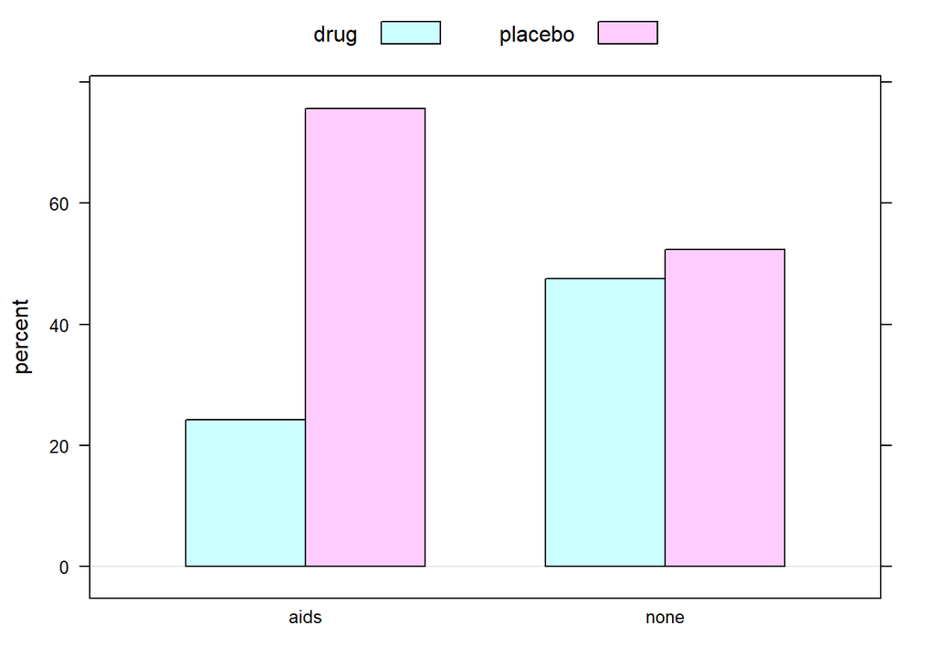

```r
barchartGC(~infected+treatment, data=avastLBGT, type='percent')
```

This bar chart here shows that the difference between the placebo and drug among LBGT population. They should definitly get the treament.

### 9.1.2 Numerical Descriptive Results

```r
genTable = xtabs(~treatment+infected, data=avastLBGT)
print(genTable)
```

```
##          infected
## treatment aids none
##   drug      34 1143
##   placebo  106 1259
```

The LGBT population should take the treatment because it signifacntly reduces aids infection. ## Inferential Results

```r
chisqtestGC(~treatment+infected, data=avastLBGT)
```

```
## Pearson's Chi-squared test with Yates' continuity correction
##
## Observed Counts:
##          infected
## treatment aids none
##   drug      34 1143
##   placebo  106 1259
##
## Counts Expected by Null:
##          infected
## treatment  aids    none
##   drug    64.82 1112.18
##   placebo 75.18 1289.82
##
## Contributions to the chi-square statistic:
##          infected
## treatment  aids  none
##   drug    14.66  0.85
##   placebo 12.64  0.74
##
##
## Chi-Square Statistic = 27.955
## Degrees of Freedom of the table = 1
## P-Value = 0
```

The inferential results say that the LBGT community should take the vaccine because it will decrese their chances of contracting aids.

# 10 Discussion and Conclusion

LBGT The results demonstrate that the vaccine is very effective in the LBGT population. The null hypothesis was that sexual orientation does not effect the effectiveness of the vaccine.